# The Politics of Corruption

Lecture 2: How to Read and Critique an Academic Article

Bogdan G. Popescu

bgpopescu@tec.mx

Tecnológico de Monterrey

## The Core Idea

An article is not a collection of facts.

It is an **argument**: evidence and assumptions, assembled to make you accept a conclusion.

Facts you memorise. Arguments you **evaluate**.

## What You Will Be Able to Do

By the end of today, with any article in any social science:

- State precisely what you are being asked to believe
- Find the assumption the authors never wrote down
- Say what else could have produced their result

## The Six Moves

```
%%{init: {"flowchart": {"useMaxWidth": true, "htmlLabels": false, "nodeSpacing": 14, "rankSpacing": 34, "padding": 16}, "themeVariables": {"fontSize": "14px", "edgeLabelBackground": "#f9fafb"}}}%%
flowchart LR
  M1["1<br/>CLAIM"] --> M2["2<br/>ARGUMENT"] --> M3["3<br/>MEASURE"] --> M4["4<br/>COMPARE"] --> M5["5<br/>RIVALS"] --> M6["6<br/>VERDICT"]
  style M1 fill:#1e293b,color:#f9fafb,stroke:#1e293b
  style M2 fill:#1e293b,color:#f9fafb,stroke:#1e293b
  style M3 fill:#4a7c6f,color:#f9fafb,stroke:#4a7c6f
  style M4 fill:#4a7c6f,color:#f9fafb,stroke:#4a7c6f
  style M5 fill:#b44527,color:#f9fafb,stroke:#b44527
  style M6 fill:#b7943a,color:#f9fafb,stroke:#b7943a
```

These are the six items of the **procedure**.

# Move 1 — The Claim

## Four Kinds of Empirical Claim

- **Descriptive** — how the world is
- **Causal effect** — X changed Y
- **Mechanism** — *why* X changed Y
- **Generalization** — it holds elsewhere too

Different claims need **different evidence**. Papers slide between them.

## One Topic, Four Claims

| **Descriptive** | Democracies rarely fight each other. |
| --- | --- |
| **Causal** | Democracy makes states less likely to fight. |
| **Mechanism** | …because leaders fear electoral punishment. |
| **General** | Any democracy, anywhere, will be peaceful. |

Evidence for the first supports **none** of the other three.

## Move 1 in Practice

Ask, before anything else:

- Which of the four is this paper’s **main** claim?
- Which does the **title** promise?
- Which does the **conclusion section** deliver?

When those three disagree, you have already found something.

# Move 2 — The Argument

## Standard Form

Strip the prose. Number the premises. Put the conclusion last.

> “Since 1816, democracies have almost never gone to war with each other. Democracy keeps the peace.”

| P1. | Pairs of democracies rarely fought each other. |
| --- | --- |
| C. | Democracy causes the peace between them. |

One premise, and a very large conclusion. Something is missing.

## The Missing Premise

| P1. | Pairs of democracies rarely fought each other. |
| --- | --- |
| P2. *(unstated)* | Their lower rate of war is not due to other shared traits, such as greater wealth, economic interdependence, or military alliances. |
| C. | Democracy causes the peace between them. |

P2 appears **nowhere** in the text — and the argument collapses without it.

An unstated premise doing real work is an **enthymeme**. Nearly every paper has one.

## Read It Charitably

Before attacking, build the **strongest** version the text supports.

- Fill in the premise the author would actually endorse
- Not the silliest one that makes them wrong
- If your version is easy to demolish, you built it wrong

A critique of a weak reconstruction tells the reader nothing.

## Where Hidden Premises Hide

Watch the words that **open** or **close** a category:

- *such as, for example, including* — opens
- *these, any of these, the* — closes
- *mere, sufficient, only, cannot, rules out* — claims a limit

> “We control for shared interests **such as** alliance, trade, and wealth — and **none of these** explains away the democratic peace.”

A paper that **opens** a category and then **closes** it a sentence later has assumed the list was complete.

That assumption is almost never stated.

# Move 3 — Measurement

## What Was Actually Observed?

The concept in the title is rarely the thing in the dataset.

| Concept claimed | Thing measured |
| --- | --- |
| democracy | a democracy index score above 6 |
| war | 1,000+ battle deaths in a year |
| shared interests | an alliance treaty on file |
| leaders fearing voters | …nothing at all |

Ask: does the measure **capture** the concept, or merely correlate with it?

## Two Levels

```
%%{init: {"flowchart": {"useMaxWidth": true, "htmlLabels": false, "nodeSpacing": 26, "rankSpacing": 60, "padding": 20}, "themeVariables": {"fontSize": "15px", "edgeLabelBackground": "#f9fafb"}}}%%
flowchart LR
  G["MEASURED<br/>country-pairs,<br/>one row per year"] -.->|"does this follow?"| I["CLAIMED<br/>individuals:<br/>voters, leaders"]
  style G fill:#4a7c6f,color:#f9fafb,stroke:#4a7c6f
  style I fill:#b44527,color:#f9fafb,stroke:#b44527
```

Move 1, row three: democracies stay peaceful **because leaders fear electoral punishment**.

What was measured: pairs of democracies fought each other less often.

**It does not follow** that any voter ever punished any leader.

Group data, individual claim: the **ecological fallacy**. Group evidence licenses group conclusions — nothing more.

# Move 4 — Comparison

## Compared to What?

> “Democracies almost never go to war with one another.”
- With how often two dictatorships fight? *(were the pairs alike?)*
- With how often *any* two states fight? *(war is rare everywhere)*
- With the same pairs before they democratized? *(were they already at peace?)*

The number is real evidence — for the **descriptive** claim.

To know whether democracy *matters*, we need to know: **compared to what?**

## Find the Assumption Sentence

Every design buys its comparison with an assumption. Good papers **write it down**.

| Design | The assumption |
| --- | --- |
| Before/after | nothing else changed at the same time |
| Treated vs. control | both groups were on parallel paths |
| Controls/matching | no unmeasured confounder is left |
| Experiment | assignment really was random |

The democratic peace lives in **controls/matching**. Its assumption is P2 from Move 2 — unstated there, written down here.

Same sentence. Whether you had to find it yourself is what separates a weak paper from a strong one.

## Then Ask One Question

Once you have found the sentence:

**Do I believe it?**

Not “is it sophisticated.” Not “did it get published.”

Can you name something concrete that would make it false?

For the democratic peace: **NATO.**

- Most postwar democracies sat inside one alliance, against one enemy — and allies do not fight each other, democratic or not.

# Move 5 — Rivals

## Generate Rivals First

Before judging the evidence, write down what **each** explanation predicts.

> “Democracies almost never fight each other. Democracy keeps the peace.”
- **Alliance** — democracies sat on the same side of the Cold War
- **Trade** — trading partners avoid war; democracies trade heavily
- **Wealth** — rich states fight less; democracies are rich
- **Reverse causation** — peace and safety let democracy survive

## The Discriminating Test

Ask of the evidence:

> Does it **discriminate**? Or would the same pattern appear under several explanations?

**The rule:** if a rival predicts the same pattern, that evidence cannot reject the rival.

All four rivals — alliance, trade, wealth, reverse causation — predict the same peace.

## Effect Is Not Explanation

**X caused Y** and **we know why X caused Y** are two separate arguments.

A design can nail the first while leaving several mechanisms alive.

Papers win the first and then write the conclusion as if they had won both.

Even if the rivals were ruled out and democracy *did* cause the peace: voters, norms, transparency — all still standing.

Row two never delivers row three.

## The Mechanical Checklist

Before crediting any explanation, rule out the boring ones:

- **Selection** — did they choose their own way into the group?
- **Time trends** — was it already heading that way anyway?
- **Ceiling/floor** — was there any room left to move?

For the democratic peace: war between *any* two states is already almost unheard of — and it has been falling since 1945.

**Floor** and **trend**. Either would produce the pattern with no democratic peace at all.

# Move 6 — Verdict

## Three Tiers, Not a Score

**Well supported** — the evidence carries this

**Plausible but not established** — consistent, not discriminated

**Not established by these data** — claimed beyond the evidence

Most papers land in all three at once. Say which is which.

## The Running Example, Judged

**Well supported:** since 1816, pairs of democracies have almost never gone to war.

**Plausible but not established:** that democracy did it, rather than alliance, trade or wealth.

**Not established by these data:** that leaders stay peaceful because they fear electoral punishment.

## A Flaw Is Not a Refutation

Finding a weakness does **not** show the conclusion is false.

- A bad argument can have a true conclusion
- “Their design has a limitation” ≠ “they are wrong”
- The verdict is about **what the evidence carries**

Your job is to locate the line between what was shown and what was said.

# The Exercise

## The Paper

Dinas, Matakos, Xefteris & Hangartner (2019), *Political Analysis*.

- **Setting:** Greek islands, 2015 refugee crisis
- **Design:** islands near Turkey received refugees; distant islands did not
- **Data:** vote shares, 95 municipalities, before and after
- **Finding:** +2 points for the far-right party Golden Dawn

The design is strong. Two strategies, placebo tests, a dose-response gradient.

## Where the Refugees Landed

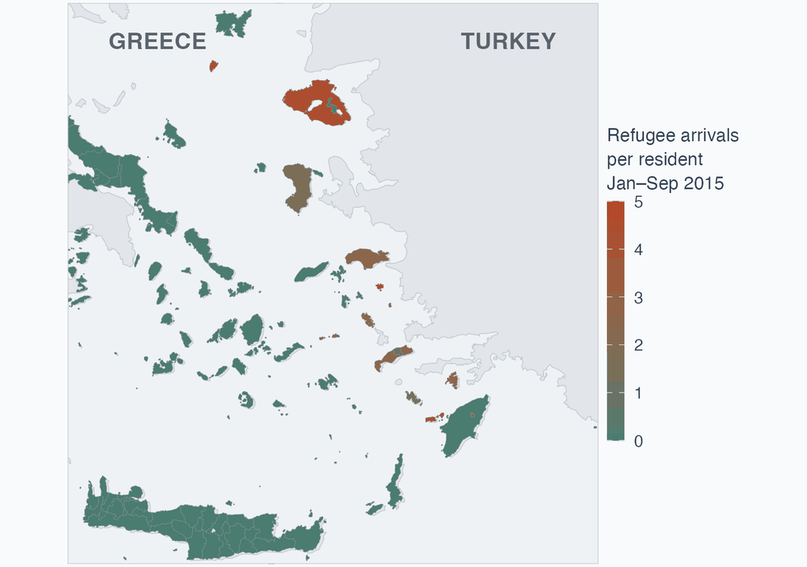

Every island that received refugees sits on the Turkish coast.

## What You Need to Know

You have not read it. Here is what the task turns on:

- Refugees stayed **under 48 hours**, then moved on to the mainland
- So the authors rule out **contact** and **resource competition** by design
- Their claimed route: arrivals → **perceived threat** → Golden Dawn vote
- The effect: **+2 points**, a 44% rise on a 4.5% base

## The Evidence

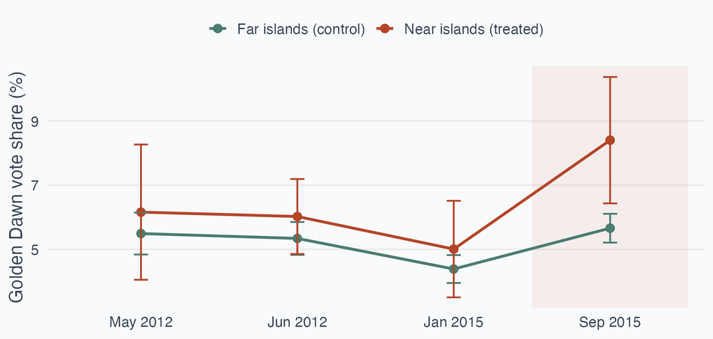

Three elections in step. Then September 2015.

## What They Conclude

Three sentences from the paper:

> “mere exposure is sufficient to **fuel prejudice** and change political behavior” (p. 247)

> competition over “scarce resources **such as** access to jobs, housing, or education… there is no specific competition… over **any of these** resources” (p. 253)

> “the **ensuing chaos** on affected islands” (p. 253)

## Your Task

**15 minutes, in pairs.** One sentence each — you are not writing an essay.

- **Move 1** *(quote 1)* — “fuels prejudice”: descriptive, causal, mechanism, or general?
- **Move 2** *(quote 2)* — write it as P1, P2, C. Which premise is never stated?
- **Move 3** *(the figure)* — what got counted, and was it counted on people or on towns?
- **Move 4** *(the map)* — what must be true of the near and far islands for this to work?
- **Move 5** — name one other thing that could lift the vote by 2 points.

Then label each of their three claims: **supported** / **plausible** / **not established**.

## Quick Answers

- **Move 1** — **mechanism**. It says *why* the vote moved: through prejudice.
- **Move 2** — unstated: that jobs, housing and education are the **only** scarce resources.
- **Move 3** — vote shares, counted on **towns**. The claim is about what is in people’s **heads**.
- **Move 4** — both groups must have been on the **same path** before 2015. The figure says they were.
- **Move 5** — disruption, or immigration dominating the news. Both predict the same 2 points.

Now three of these, properly.

## Reveal 1 — The Hidden Premise

| P1. | Group conflict needs competition over scarce resources. |
| --- | --- |
| P2. | No competition over jobs, housing, or education. |
| P3. *(unstated)* | Those three **are** the relevant scarce resources. |
| C. | So group conflict does not explain the backlash. |

“**such as**” opens the category. “**any of these**” closes it. P3 is never defended.

Policing, transport, clinics, public space — also scarce. The authors’ own phrase: *“ensuing chaos.”*

## Reveal 2 — Two Jumps

```
%%{init: {"flowchart": {"useMaxWidth": true, "htmlLabels": false, "nodeSpacing": 26, "rankSpacing": 50, "padding": 18}, "themeVariables": {"fontSize": "14px", "edgeLabelBackground": "#f9fafb"}}}%%
flowchart LR
  V["MEASURED<br/>town vote shares"] -.->|"group to individual"| I["individual<br/>voters"]
  I -.->|"votes to minds"| P["CLAIMED<br/>prejudice"]
  style V fill:#4a7c6f,color:#f9fafb,stroke:#4a7c6f
  style I fill:#f9fafb,color:#334155,stroke:#64748b
  style P fill:#b44527,color:#f9fafb,stroke:#b44527
```

Prejudice is never measured. The outcome is a vote share.

**They measured votes, not prejudice.**

## Reveal 3 — Rivals

```
%%{init: {"flowchart": {"useMaxWidth": true, "htmlLabels": false, "nodeSpacing": 20, "rankSpacing": 66, "padding": 18}, "themeVariables": {"fontSize": "14px", "edgeLabelBackground": "#f9fafb"}}}%%
flowchart LR
  A["A. Mere exposure<br/>seeing refugees"] --> R["Golden Dawn<br/>vote rises"]
  B["B. Disruption<br/>chaos, strained services"] --> R
  C["C. Salience<br/>immigration dominates news"] --> R
  style A fill:#b44527,color:#f9fafb,stroke:#b44527
  style B fill:#f9fafb,color:#334155,stroke:#64748b
  style C fill:#f9fafb,color:#334155,stroke:#64748b
  style R fill:#1e293b,color:#f9fafb,stroke:#1e293b
```

All three predict the same result. The evidence does not discriminate.

## The Calibrated Verdict

**Well supported:** refugee arrivals raised Golden Dawn’s vote share by ~2 points.

**Plausible, not established:** that *seeing refugees* did it, rather than the disruption around them.

**Not established by these data:** that anyone’s prejudice changed.

This is a **good paper**. Notice that the verdict still has three tiers.

# The Handout

## Six Moves

1. **CLAIM** — what exactly am I asked to believe?
2. **ARGUMENT** — P1, P2, hidden P3, C?
3. **MEASUREMENT** — what was measured, at what level?
4. **COMPARISON** — compared with what, on what assumption?
5. **RIVALS** — what else predicts this? does it discriminate?
6. **VERDICT** — supported / plausible / not established